# Polymarket Bias & Mispricing Analysis

Closed Markets 2025 — Calibration, Drift, Breakouts & Exploitable Patterns (v3)

Laurence

2026-02-18

# 1 · Setup & Data Loading

```r
library(arrow)
library(dplyr)
library(tidyr)
library(stringr)
library(ggplot2)
library(jsonlite)
library(lubridate)
library(scales)
library(purrr)
library(boot)       # bootstrap CIs
library(data.table)

theme_poly <- theme_minimal(base_size = 13) +
  theme(
    plot.title    = element_text(face = "bold", size = 15),
    plot.subtitle = element_text(color = "grey40"),
    panel.grid.minor = element_blank(),
    legend.position = "bottom"
  )
theme_set(theme_poly)

COL_POS  <- "#2ecc71"
COL_NEG  <- "#e74c3c"
COL_NEUT <- "grey70"
```

```r
df <- read_parquet("../data/markets_2025_closed.parquet")
cat(nrow(df), "market rows loaded\n")
```

```
## 111178 market rows loaded
```

```r
cat(ncol(df), "columns\n")
```

```
## 87 columns
```

## 1.1 Parse Resolutions & Token Mapping

```r
safe_parse_json <- function(x) tryCatch(fromJSON(x), error = function(e) NA)

df_parsed <- df %>%
  filter(closed == TRUE) %>%
  rowwise() %>%
  mutate(
    outcomes_list = list(tryCatch(fromJSON(outcomes),      error = function(e) NA_character_)),
    prices_list   = list(tryCatch(fromJSON(outcome_prices), error = function(e) NA_character_)),
    tokens_list   = list(tryCatch(fromJSON(token_ids),      error = function(e) NA_character_))
  ) %>%
  ungroup()

df_binary <- df_parsed %>%
  mutate(
    n_outcomes = lengths(outcomes_list),
    is_binary  = n_outcomes == 2,
    yes_idx    = map_int(outcomes_list, ~ {
      idx <- which(tolower(.x) == "yes")
      if (length(idx) == 1) idx else NA_integer_
    })
  ) %>%
  filter(is_binary, !is.na(yes_idx)) %>%
  mutate(
    yes_token_id   = map2_chr(tokens_list, yes_idx, ~ .x[.y]),
    yes_resolution = map2_dbl(prices_list, yes_idx, ~ as.numeric(.x[.y])),
    no_idx         = ifelse(yes_idx == 1, 2, 1),
    no_token_id    = map2_chr(tokens_list, no_idx, ~ .x[.y])
  ) %>%
  filter(!is.na(yes_resolution), yes_resolution %in% c(0, 1))

cat(nrow(df_binary), "binary Yes/No markets with clean resolution\n")
```

```
## 49753 binary Yes/No markets with clean resolution
```

```r
cat("Resolution rate (Yes = 1):", round(mean(df_binary$yes_resolution), 3), "\n")
```

```
## Resolution rate (Yes = 1): 0.267
```

## 1.2 Derive Categories from Tags

```r
category_rules <- tibble::tribble(
  ~category,       ~pattern,
  "Sports",        "nba|nfl|mlb|nhl|soccer|football|tennis|boxing|mma|ufc|cricket|esports|dota|league of legends|sports|epl|la liga|bundesliga|serie a|ligue 1|f1|formula|nascar|golf|olympics|pga",
  "Crypto",        "crypto|bitcoin|btc|ethereum|eth|solana|sol|defi|blockchain|token|nft|altcoin|memecoin|binance|coinbase",
  "Politics",      "politic|election|trump|biden|democrat|republican|congress|senate|governor|president|vote|gop|dnc|rnc|parliament|minister|legislation|bill|law|executive order",
  "Economics",     "econom|fed |federal reserve|interest rate|inflation|gdp|employment|jobs|recession|tariff|trade|stock market|s&p|nasdaq|dow jones|treasury|debt|cpi",
  "Science/Tech",  "science|tech|ai |artificial intelligence|openai|google|apple|microsoft|space|spacex|nasa|climate|weather|earthquake|hurricane|temperature",
  "Entertainment", "movie|film|oscar|grammy|emmy|music|album|box office|streaming|netflix|youtube|tiktok|celebrity|award|tv show|series",
  "World Events",  "war|conflict|ukraine|russia|china|israel|gaza|nato|united nations|refugee|disaster|pandemic",
  "Other",         ".*"
)

assign_category <- function(tags) {
  if (is.na(tags) || tags == "") return("Other")
  combined <- tolower(tags)
  for (i in seq_len(nrow(category_rules))) {
    if (str_detect(combined, category_rules$pattern[i])) return(category_rules$category[i])
  }
  "Other"
}

df_binary <- df_binary %>%
  mutate(
    category    = map_chr(event_tags, assign_category),
    # Tag likely election-cycle markets within Politics
    is_election = category == "Politics" &
      str_detect(tolower(event_tags),
        "trump|biden|harris|presidential|house|senate|congress|election 2024|midterm|ballot")
  )

cat("\n── Category distribution ──\n")
```

```
##
## ── Category distribution ──
```

```r
df_binary %>% count(category, sort = TRUE) %>% print()
```

```
## # A tibble: 8 × 2
##   category          n
##   <chr>         <int>
## 1 Sports        14881
## 2 Crypto        14161
## 3 Politics       9844
## 4 Science/Tech   5570
## 5 Other          2410
## 6 Entertainment  2091
## 7 Economics       777
## 8 World Events     19
```

```r
cat("\nPolitics: election-tagged =",
    sum(df_binary$is_election, na.rm = TRUE), "/",
    sum(df_binary$category == "Politics"), "\n")
```

```
##
## Politics: election-tagged = 4628 / 9844
```

# 2 · Calibration Analysis (Snapshot Prices)

The core question: **when the market prices a Yes token at probability $p$, does the event actually happen $p$% of the time?**

```r
token_lookup <- df_binary %>%
  select(yes_token_id, yes_resolution, id, event_title, category,
         is_election, closed_time, volume_num) %>%
  rename(token_id = yes_token_id) %>%
  mutate(closed_dt = ymd_hms(closed_time, quiet = TRUE)) %>%
  filter(!is.na(closed_dt))

yes_tokens <- unique(token_lookup$token_id)
cat(length(yes_tokens), "unique Yes tokens to look up\n")
```

```
## 49753 unique Yes tokens to look up
```

```r
dfp_arrow <- open_dataset(
  "../data/markets_2025_closed_price_history.parquet"
)

snapshots       <- c(1, 6, 24, 72, 168, 720)
snapshot_labels <- c("1h", "6h", "1d", "3d", "1w", "1mo")

BATCH_SIZE    <- 500
token_batches <- split(yes_tokens, ceiling(seq_along(yes_tokens) / BATCH_SIZE))
cat(length(token_batches), "batches of up to", BATCH_SIZE, "tokens\n")
```

```
## 100 batches of up to 500 tokens
```

```r
get_snapshot_price <- function(hbc, price, target_hours) {
  diffs <- abs(hbc - target_hours)
  valid <- diffs < (target_hours * 0.5 + 1)
  if (!any(valid)) return(NA_real_)
  price[valid][which.min(diffs[valid])]
}

snapshot_list  <- vector("list", length(token_batches))
mkt_stats_list <- vector("list", length(token_batches))

for (i in seq_along(token_batches)) {
  batch_tokens <- token_batches[[i]]

  batch_prices <- dfp_arrow %>%
    filter(token_id %in% batch_tokens) %>%
    select(token_id, timestamp, price) %>%
    collect()

  if (nrow(batch_prices) == 0) next

  batch_prices <- batch_prices %>%
    inner_join(
      token_lookup %>% select(token_id, yes_resolution, id, category,
                               is_election, volume_num, closed_dt),
      by = "token_id"
    ) %>%
    mutate(hours_before_close = as.numeric(
      difftime(closed_dt, timestamp, units = "hours")
    )) %>%
    filter(hours_before_close >= 0)

  if (nrow(batch_prices) == 0) next

  # ── Snapshot prices ───────────────────────────────────────────────
  batch_snap <- batch_prices %>%
    group_by(token_id, id, yes_resolution, category, is_election, volume_num) %>%
    summarise(
      across_snapshots = list(tibble(
        snapshot_hours = snapshots,
        snapshot_label = snapshot_labels,
        snap_price     = map_dbl(snapshots, ~ get_snapshot_price(hours_before_close, price, .x))
      )),
      .groups = "drop"
    ) %>%
    unnest(across_snapshots) %>%
    filter(!is.na(snap_price))

  snapshot_list[[i]] <- batch_snap

  # ── Per-market summary stats (for drift/breakout/duration analyses) ─
  mkt_summary <- batch_prices %>%
    arrange(token_id, desc(hours_before_close)) %>%
    group_by(token_id, id, yes_resolution, category, is_election, volume_num, closed_dt) %>%
    summarise(
      initial_price      = first(price),
      final_price        = last(price),
      min_price          = min(price),
      max_price          = max(price),
      price_range        = max(price) - min(price),
      n_obs              = n(),
      market_duration_h  = max(hours_before_close),
      price_sd           = if_else(n() > 2, sd(price), NA_real_),
      .groups            = "drop"
    )

  mkt_stats_list[[i]] <- mkt_summary

  if (i %% 5 == 0 || i == length(token_batches)) {
    cat(sprintf("  Batch %d/%d done (%d snapshot rows so far)\n",
                i, length(token_batches),
                sum(map_int(snapshot_list, ~ if (is.null(.x)) 0L else nrow(.x)))))
  }

  rm(batch_prices, batch_snap, mkt_summary); gc(verbose = FALSE)
}
```

```
##   Batch 5/100 done (11595 snapshot rows so far)
##   Batch 10/100 done (23809 snapshot rows so far)
##   Batch 15/100 done (36470 snapshot rows so far)
##   Batch 20/100 done (48962 snapshot rows so far)
##   Batch 25/100 done (61591 snapshot rows so far)
##   Batch 30/100 done (74504 snapshot rows so far)
##   Batch 35/100 done (87249 snapshot rows so far)
##   Batch 40/100 done (100113 snapshot rows so far)
##   Batch 45/100 done (112551 snapshot rows so far)
##   Batch 50/100 done (123420 snapshot rows so far)
##   Batch 55/100 done (133622 snapshot rows so far)
##   Batch 60/100 done (145422 snapshot rows so far)
##   Batch 65/100 done (157735 snapshot rows so far)
##   Batch 70/100 done (169985 snapshot rows so far)
##   Batch 75/100 done (181988 snapshot rows so far)
##   Batch 80/100 done (194828 snapshot rows so far)
##   Batch 85/100 done (207703 snapshot rows so far)
##   Batch 90/100 done (220378 snapshot rows so far)
##   Batch 95/100 done (232904 snapshot rows so far)
##   Batch 100/100 done (245827 snapshot rows so far)
```

```r
snapshot_data <- bind_rows(snapshot_list)
market_stats  <- bind_rows(mkt_stats_list)
rm(snapshot_list, mkt_stats_list, dfp_arrow); gc()
```

```
##            used  (Mb) gc trigger  (Mb)  max used  (Mb)
## Ncells  3526446 188.4    6073394 324.4   6073394 324.4
## Vcells 43049468 328.5  121387422 926.2 121386354 926.2
```

```r
cat("\n", nrow(snapshot_data), "total market × snapshot observations\n")
```

```
##
##  245827 total market × snapshot observations
```

```r
cat(nrow(market_stats), "markets with full price history stats\n")
```

```
## 49753 markets with full price history stats
```

## 2.1 Overall Calibration Curve

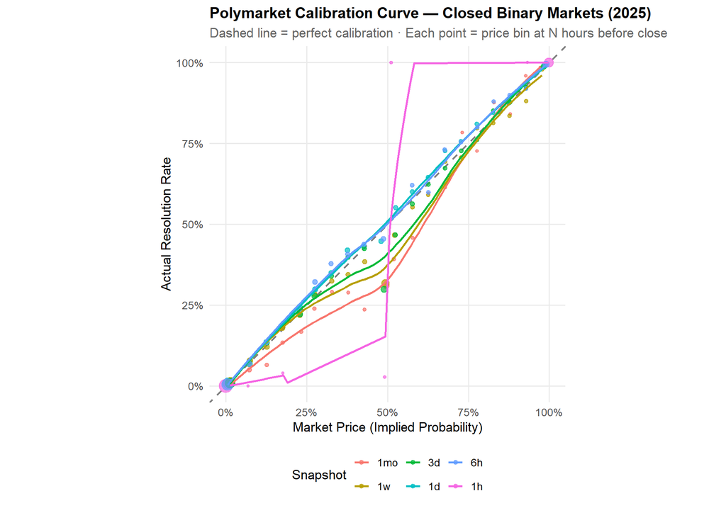

```r
calibration <- snapshot_data %>%
  mutate(
    price_bin    = cut(snap_price, breaks = seq(0, 1, by = 0.05),
                       include.lowest = TRUE, labels = FALSE),
    bin_midpoint = (price_bin - 1) * 0.05 + 0.025
  ) %>%
  filter(!is.na(price_bin)) %>%
  group_by(snapshot_label, bin_midpoint) %>%
  summarise(n = n(), actual_pct = mean(yes_resolution), avg_price = mean(snap_price), .groups = "drop") %>%
  mutate(snapshot_label = factor(snapshot_label, levels = c("1mo","1w","3d","1d","6h","1h")))

ggplot(calibration %>% filter(n >= 20), aes(x = avg_price, y = actual_pct)) +
  geom_abline(slope = 1, intercept = 0, linetype = "dashed", color = "grey50", linewidth = 0.8) +
  geom_point(aes(size = n, color = snapshot_label), alpha = 0.7) +
  geom_smooth(aes(color = snapshot_label, weight = n), method = "loess", se = FALSE, linewidth = 1) +
  scale_x_continuous(labels = percent, limits = c(0,1)) +
  scale_y_continuous(labels = percent, limits = c(0,1)) +
  scale_size_continuous(range = c(1,6), guide = "none") +
  coord_equal() +
  labs(
    title    = "Polymarket Calibration Curve — Closed Binary Markets (2025)",
    subtitle = "Dashed line = perfect calibration · Each point = price bin at N hours before close",
    x = "Market Price (Implied Probability)", y = "Actual Resolution Rate", color = "Snapshot"
  )
```

## 2.2 Calibration Error by Snapshot Horizon

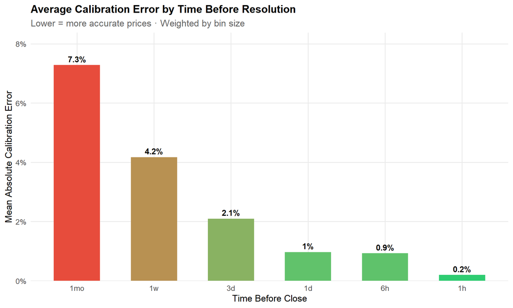

```r
cal_error <- snapshot_data %>%
  mutate(price_bin = round(snap_price * 20) / 20) %>%
  group_by(snapshot_label, price_bin) %>%
  summarise(n = n(), actual = mean(yes_resolution), predicted = mean(snap_price), .groups = "drop") %>%
  filter(n >= 10) %>%
  group_by(snapshot_label) %>%
  summarise(
    weighted_cal_error = weighted.mean(abs(actual - predicted), w = n),
    n_bins             = n(),
    total_obs          = sum(n),
    .groups            = "drop"
  ) %>%
  mutate(snapshot_label = factor(snapshot_label, levels = c("1mo","1w","3d","1d","6h","1h")))

ggplot(cal_error, aes(x = snapshot_label, y = weighted_cal_error)) +
  geom_col(aes(fill = weighted_cal_error), width = 0.6, show.legend = FALSE) +
  geom_text(aes(label = paste0(round(weighted_cal_error*100,1),"%")),
            vjust = -0.5, fontface = "bold", size = 4) +
  scale_fill_gradient(low = COL_POS, high = COL_NEG) +
  scale_y_continuous(labels = percent, expand = expansion(mult = c(0, 0.15))) +
  labs(
    title    = "Average Calibration Error by Time Before Resolution",
    subtitle = "Lower = more accurate prices · Weighted by bin size",
    x = "Time Before Close", y = "Mean Absolute Calibration Error"
  )
```

## 2.3 Favorite–Longshot Bias

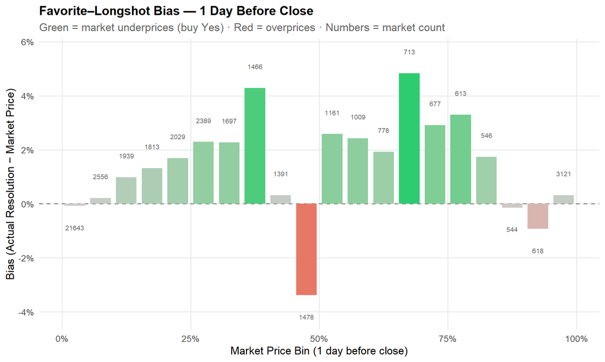

```r
fl_data <- snapshot_data %>%
  filter(snapshot_label == "1d") %>%
  mutate(
    price_bin    = cut(snap_price, breaks = seq(0,1,by=0.05),
                       include.lowest = TRUE, labels = FALSE),
    bin_midpoint = (price_bin - 1) * 0.05 + 0.025
  ) %>%
  filter(!is.na(price_bin)) %>%
  group_by(bin_midpoint) %>%
  summarise(
    n = n(), actual = mean(yes_resolution), predicted = mean(snap_price),
    bias = actual - predicted, .groups = "drop"
  )

ggplot(fl_data %>% filter(n >= 15), aes(x = bin_midpoint, y = bias)) +
  geom_hline(yintercept = 0, linetype = "dashed", color = "grey50") +
  geom_col(aes(fill = bias), width = 0.04, show.legend = FALSE) +
  geom_text(aes(label = n, y = ifelse(bias >= 0, bias + 0.008, bias - 0.008)),
            size = 2.8, color = "grey40") +
  scale_fill_gradient2(low = COL_NEG, mid = "grey80", high = COL_POS, midpoint = 0) +
  scale_x_continuous(labels = percent) +
  scale_y_continuous(labels = percent) +
  labs(
    title    = "Favorite–Longshot Bias — 1 Day Before Close",
    subtitle = "Green = market underprices (buy Yes) · Red = overprices · Numbers = market count",
    x = "Market Price Bin (1 day before close)", y = "Bias (Actual Resolution − Market Price)"
  )
```

## 2.4 Initial Price Bias

**New.** We compare the *earliest* recorded price per market to its resolution. This tests whether market creators systematically anchor opening prices too high or too low — a bias that is separate from, and often larger than, near-close mispricing.

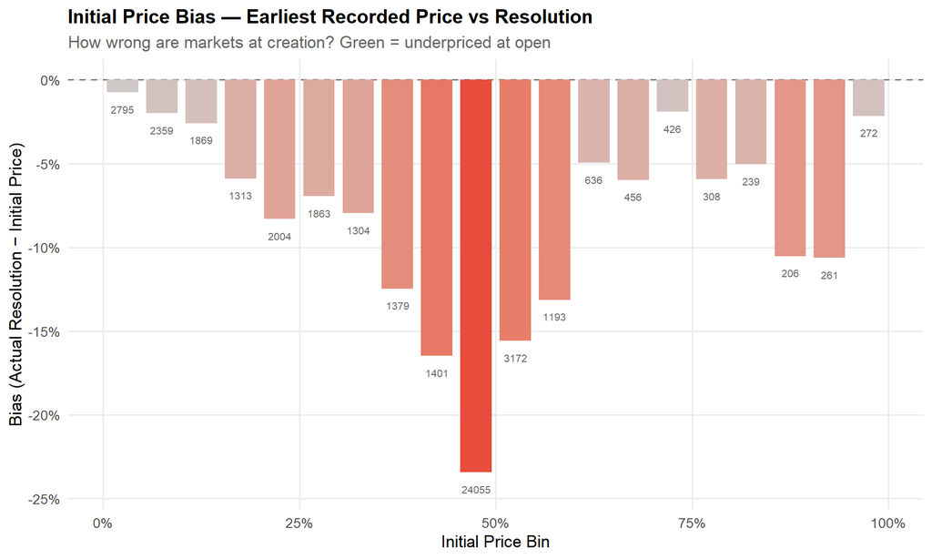

```r
initial_bias <- market_stats %>%
  filter(!is.na(initial_price), !is.na(yes_resolution), market_duration_h >= 24) %>%
  mutate(
    init_bin     = cut(initial_price, breaks = seq(0,1,by=0.05),
                       include.lowest = TRUE, labels = FALSE),
    bin_midpoint = (init_bin - 1) * 0.05 + 0.025
  ) %>%
  filter(!is.na(init_bin)) %>%
  group_by(bin_midpoint) %>%
  summarise(
    n           = n(),
    actual_rate = mean(yes_resolution),
    avg_init    = mean(initial_price),
    init_bias   = mean(yes_resolution) - mean(initial_price),
    .groups     = "drop"
  )

ggplot(initial_bias %>% filter(n >= 15), aes(x = bin_midpoint, y = init_bias)) +
  geom_hline(yintercept = 0, linetype = "dashed", color = "grey50") +
  geom_col(aes(fill = init_bias), width = 0.04, show.legend = FALSE) +
  geom_text(aes(label = n, y = ifelse(init_bias >= 0, init_bias + 0.01, init_bias - 0.01)),
            size = 2.8, color = "grey40") +
  scale_fill_gradient2(low = COL_NEG, mid = "grey80", high = COL_POS, midpoint = 0) +
  scale_x_continuous(labels = percent) +
  scale_y_continuous(labels = percent) +
  labs(
    title    = "Initial Price Bias — Earliest Recorded Price vs Resolution",
    subtitle = "How wrong are markets at creation? Green = underpriced at open",
    x = "Initial Price Bin", y = "Bias (Actual Resolution − Initial Price)"
  )
```

```r
init_vs_close <- market_stats %>%
  filter(!is.na(initial_price), market_duration_h >= 24) %>%
  left_join(
    snapshot_data %>%
      filter(snapshot_label == "1d") %>%
      select(id, snap_price) %>%
      rename(close_price_1d = snap_price),
    by = "id"
  ) %>%
  filter(!is.na(close_price_1d)) %>%
  summarise(
    initial_bias  = mean(yes_resolution - initial_price),
    close_1d_bias = mean(yes_resolution - close_price_1d),
    n             = n()
  )

cat("── Initial vs 1-day-before-close bias comparison ──\n")
```

```
## ── Initial vs 1-day-before-close bias comparison ──
```

```r
cat(sprintf("  At market open:      %+.2f%%\n", init_vs_close$initial_bias  * 100))
```

```
##   At market open:      -15.65%
```

```r
cat(sprintf("  1 day before close:  %+.2f%%\n", init_vs_close$close_1d_bias * 100))
```

```
##   1 day before close:  +0.75%
```

```r
cat(sprintf("  Markets compared:    %d\n",       init_vs_close$n))
```

```
##   Markets compared:    47508
```

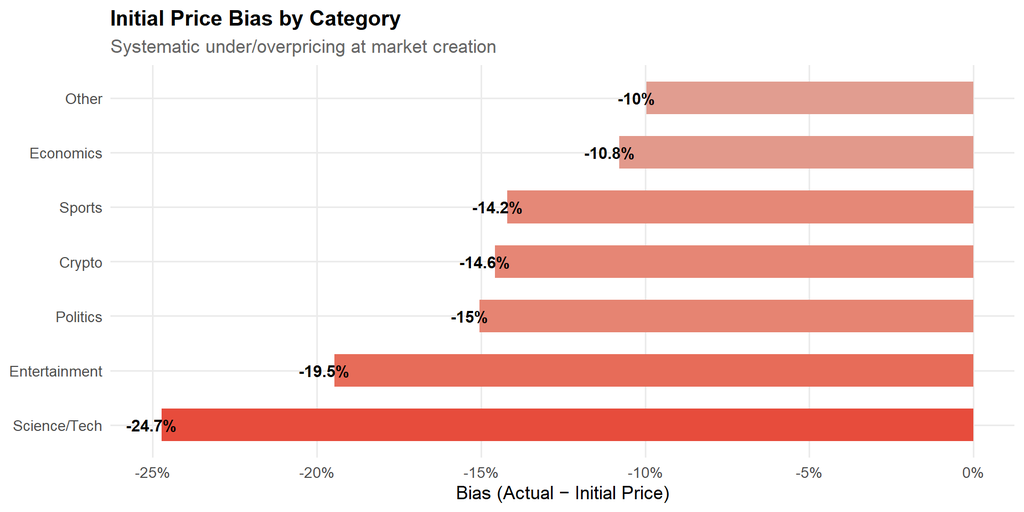

```r
init_cat_bias <- market_stats %>%
  filter(!is.na(initial_price), market_duration_h >= 24) %>%
  group_by(category) %>%
  summarise(
    n            = n(),
    initial_bias = mean(yes_resolution - initial_price),
    .groups      = "drop"
  ) %>%
  filter(n >= 20)

ggplot(init_cat_bias, aes(x = reorder(category, initial_bias), y = initial_bias)) +
  geom_col(aes(fill = initial_bias), width = 0.6, show.legend = FALSE) +
  geom_text(aes(label = paste0(ifelse(initial_bias > 0, "+", ""),
                                round(initial_bias * 100, 1), "%"),
                y = initial_bias + sign(initial_bias) * 0.003),
            fontface = "bold", size = 4) +
  scale_fill_gradient2(low = COL_NEG, mid = "grey80", high = COL_POS, midpoint = 0) +
  scale_y_continuous(labels = percent) +
  coord_flip() +
  labs(
    title    = "Initial Price Bias by Category",
    subtitle = "Systematic under/overpricing at market creation",
    x = NULL, y = "Bias (Actual − Initial Price)"
  )
```

## 2.5 Price Drift Over Market Lifetime

**New.** How do prices evolve from open to close? Do they drift monotonically toward resolution, or overshoot and correct?

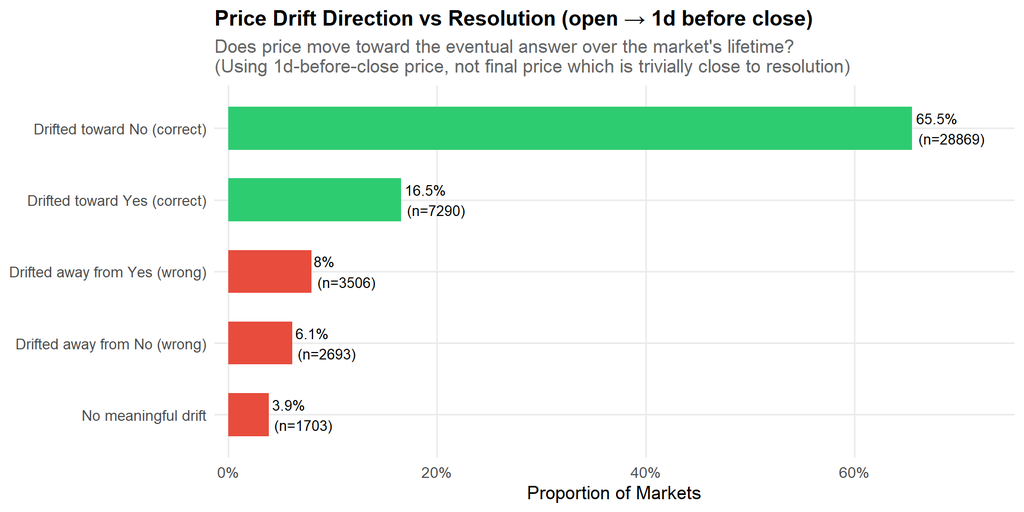

```r
# Use 1d-before-close snapshot instead of final_price (which is ~resolution itself)
drift_data <- market_stats %>%
  filter(!is.na(initial_price), market_duration_h >= 48) %>%
  inner_join(
    snapshot_data %>%
      filter(snapshot_label == "1d") %>%
      select(id, snap_price) %>%
      rename(price_1d = snap_price),
    by = "id"
  ) %>%
  mutate(
    total_drift   = price_1d - initial_price,
    drift_correct = case_when(
      yes_resolution == 1 & total_drift >  0.01  ~ "Drifted toward Yes (correct)",
      yes_resolution == 0 & total_drift < -0.01  ~ "Drifted toward No (correct)",
      yes_resolution == 1 & total_drift < -0.01  ~ "Drifted away from Yes (wrong)",
      yes_resolution == 0 & total_drift >  0.01  ~ "Drifted away from No (wrong)",
      TRUE                                        ~ "No meaningful drift"
    )
  )

drift_summary <- drift_data %>%
  count(drift_correct) %>%
  mutate(pct = n / sum(n))

ggplot(drift_summary, aes(x = reorder(drift_correct, pct), y = pct)) +
  geom_col(aes(fill = str_detect(drift_correct, "correct")), width = 0.6, show.legend = FALSE) +
  geom_text(aes(label = paste0(round(pct*100,1), "%\n(n=", n, ")")),
            hjust = -0.1, size = 3.5) +
  scale_fill_manual(values = c("FALSE" = COL_NEG, "TRUE" = COL_POS)) +
  scale_y_continuous(labels = percent, expand = expansion(mult = c(0.02, 0.15))) +
  coord_flip() +
  labs(
    title    = "Price Drift Direction vs Resolution (open → 1d before close)",
    subtitle = "Does price move toward the eventual answer over the market's lifetime?\n(Using 1d-before-close price, not final price which is trivially close to resolution)",
    x = NULL, y = "Proportion of Markets"
  )
```

```r
range_bias <- market_stats %>%
  filter(!is.na(price_range), market_duration_h >= 24) %>%
  inner_join(
    snapshot_data %>%
      filter(snapshot_label == "1d") %>%
      select(id, snap_price) %>%
      rename(price_1d = snap_price),
    by = "id"
  ) %>%
  mutate(
    range_tier = case_when(
      price_range < 0.10 ~ "Low (<10pp)",
      price_range < 0.30 ~ "Medium (10-30pp)",
      price_range < 0.60 ~ "High (30-60pp)",
      TRUE               ~ "Very High (>60pp)"
    ),
    range_tier = factor(range_tier, levels = c(
      "Low (<10pp)", "Medium (10-30pp)", "High (30-60pp)", "Very High (>60pp)"
    ))
  ) %>%
  group_by(range_tier) %>%
  summarise(
    n            = n(),
    resolution   = mean(yes_resolution),
    init_bias    = mean(yes_resolution - initial_price),
    final_bias   = mean(yes_resolution - price_1d),
    brier_init   = mean((initial_price - yes_resolution)^2),
    .groups      = "drop"
  )

range_bias %>%
  mutate(across(where(is.numeric), ~ round(.x, 4))) %>%
  knitr::kable(caption = "Calibration Quality by Price Range (market volatility)")
```

Calibration Quality by Price Range (market volatility)

| range_tier | n | resolution | init_bias | final_bias | brier_init |
| --- | --- | --- | --- | --- | --- |
| Low (<10pp) | 2795 | 0.0497 | -0.0378 | -0.0053 | 0.0024 |
| Medium (10-30pp) | 5016 | 0.0889 | -0.1321 | -0.0342 | 0.0327 |
| High (30-60pp) | 26520 | 0.1592 | -0.2989 | -0.0533 | 0.2061 |
| Very High (>60pp) | 13177 | 0.5653 | 0.0955 | 0.1483 | 0.2993 |

# 3 · Category-Level Mispricings

## 3.1 Category Calibration Curves

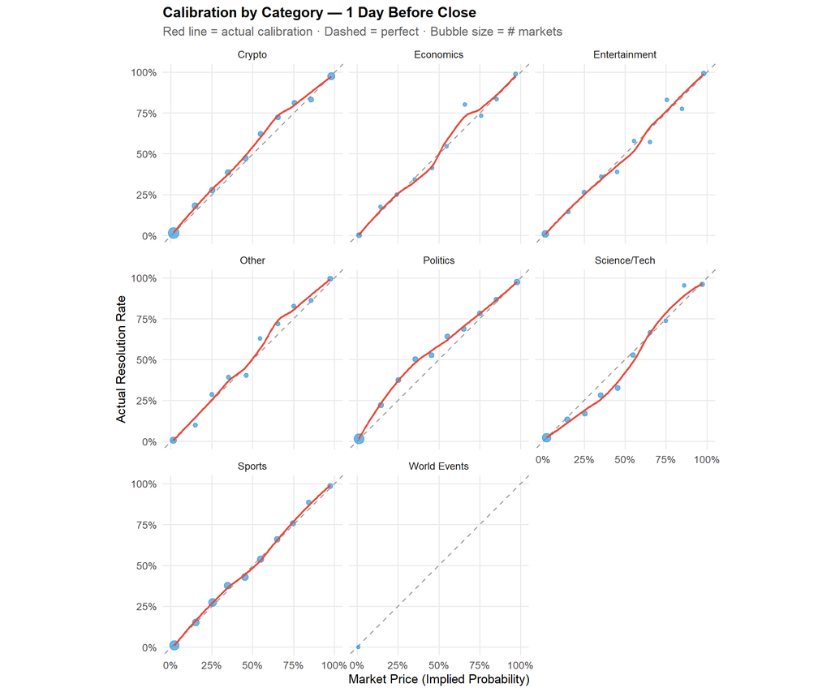

```r
cat_cal <- snapshot_data %>%
  filter(snapshot_label == "1d") %>%
  mutate(
    price_bin    = cut(snap_price, breaks = seq(0,1,by=0.10),
                       include.lowest = TRUE, labels = FALSE),
    bin_midpoint = (price_bin - 1) * 0.10 + 0.05
  ) %>%
  filter(!is.na(price_bin)) %>%
  group_by(category, bin_midpoint) %>%
  summarise(n = n(), actual = mean(yes_resolution), predicted = mean(snap_price), .groups = "drop")

ggplot(cat_cal %>% filter(n >= 10), aes(x = predicted, y = actual)) +
  geom_abline(slope = 1, intercept = 0, linetype = "dashed", color = "grey60") +
  geom_point(aes(size = n), color = "#3498db", alpha = 0.7) +
  geom_smooth(aes(weight = n), method = "loess", se = FALSE, color = COL_NEG, linewidth = 1) +
  facet_wrap(~ category, ncol = 3) +
  scale_x_continuous(labels = percent, limits = c(0,1)) +
  scale_y_continuous(labels = percent, limits = c(0,1)) +
  scale_size_continuous(range = c(1.5,5), guide = "none") +
  coord_equal() +
  labs(
    title    = "Calibration by Category — 1 Day Before Close",
    subtitle = "Red line = actual calibration · Dashed = perfect · Bubble size = # markets",
    x = "Market Price (Implied Probability)", y = "Actual Resolution Rate"
  )
```

## 3.2 Category Bias Heatmap

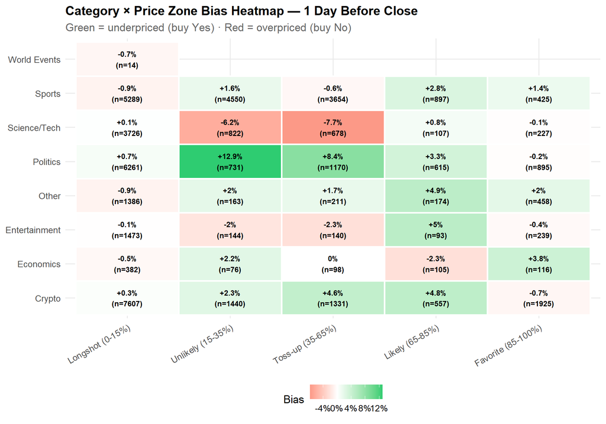

```r
cat_bias <- snapshot_data %>%
  filter(snapshot_label == "1d") %>%
  mutate(
    price_zone = case_when(
      snap_price <= 0.15 ~ "Longshot (0-15%)",
      snap_price <= 0.35 ~ "Unlikely (15-35%)",
      snap_price <= 0.65 ~ "Toss-up (35-65%)",
      snap_price <= 0.85 ~ "Likely (65-85%)",
      TRUE               ~ "Favorite (85-100%)"
    ),
    price_zone = factor(price_zone, levels = c(
      "Longshot (0-15%)", "Unlikely (15-35%)", "Toss-up (35-65%)",
      "Likely (65-85%)", "Favorite (85-100%)"
    ))
  ) %>%
  group_by(category, price_zone) %>%
  summarise(n = n(), bias = mean(yes_resolution) - mean(snap_price), .groups = "drop") %>%
  filter(n >= 10)

ggplot(cat_bias, aes(x = price_zone, y = category, fill = bias)) +
  geom_tile(color = "white", linewidth = 1) +
  geom_text(aes(label = paste0(ifelse(bias > 0,"+",""), round(bias*100,1),"%\n(n=",n,")")),
            size = 3.2, fontface = "bold") +
  scale_fill_gradient2(low = COL_NEG, mid = "white", high = COL_POS, midpoint = 0,
                       labels = percent, name = "Bias") +
  labs(
    title    = "Category × Price Zone Bias Heatmap — 1 Day Before Close",
    subtitle = "Green = underpriced (buy Yes) · Red = overpriced (buy No)",
    x = NULL, y = NULL
  ) +
  theme(axis.text.x = element_text(angle = 30, hjust = 1))
```

## 3.3 Aggregate Category Bias & Brier Score

```r
cat_stats <- snapshot_data %>%
  filter(snapshot_label == "1d") %>%
  group_by(category) %>%
  summarise(
    n_markets       = n(),
    avg_price       = mean(snap_price),
    resolution_rate = mean(yes_resolution),
    bias            = mean(yes_resolution) - mean(snap_price),
    brier_score     = mean((snap_price - yes_resolution)^2),
    abs_bias        = mean(abs(yes_resolution - snap_price)),
    .groups         = "drop"
  ) %>%
  arrange(desc(abs(bias)))

cat_stats %>%
  mutate(across(where(is.numeric), ~ round(.x, 4))) %>%
  knitr::kable(caption = "Category-Level Bias & Accuracy (1 day before close)")
```

Category-Level Bias & Accuracy (1 day before close)

| category | n_markets | avg_price | resolution_rate | bias | brier_score | abs_bias |
| --- | --- | --- | --- | --- | --- | --- |
| World Events | 18 | 0.1137 | 0.2222 | 0.1085 | 0.0650 | 0.1193 |
| Politics | 9672 | 0.2265 | 0.2529 | 0.0264 | 0.0755 | 0.1431 |
| Science/Tech | 5560 | 0.1656 | 0.1480 | -0.0176 | 0.0743 | 0.1533 |
| Crypto | 12860 | 0.2694 | 0.2796 | 0.0102 | 0.0732 | 0.1438 |
| Other | 2392 | 0.3098 | 0.3148 | 0.0050 | 0.0554 | 0.1200 |
| Sports | 14815 | 0.2823 | 0.2846 | 0.0022 | 0.1407 | 0.2826 |
| Economics | 777 | 0.3403 | 0.3423 | 0.0020 | 0.0846 | 0.1735 |
| Entertainment | 2089 | 0.2061 | 0.2044 | -0.0017 | 0.0473 | 0.0972 |

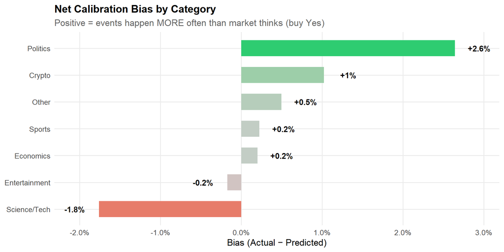

```r
ggplot(cat_stats %>% filter(n_markets >= 20),
       aes(x = reorder(category, bias), y = bias)) +
  geom_col(aes(fill = bias), width = 0.6, show.legend = FALSE) +
  geom_text(aes(label = paste0(ifelse(bias > 0,"+",""), round(bias*100,1),"%"),
                y = bias + sign(bias) * 0.003),
            fontface = "bold", size = 4) +
  scale_fill_gradient2(low = COL_NEG, mid = "grey80", high = COL_POS, midpoint = 0) +
  scale_y_continuous(labels = percent) +
  coord_flip() +
  labs(
    title    = "Net Calibration Bias by Category",
    subtitle = "Positive = events happen MORE often than market thinks (buy Yes)",
    x = NULL, y = "Bias (Actual − Predicted)"
  )
```

## 3.4 Politics: Election vs. Non-Election Markets

**New.** The Politics category shows the strongest aggregate bias (+2.6%). We check how much of this is 2024 US election spillover — if the edge is election-specific, it may not persist in 2026.

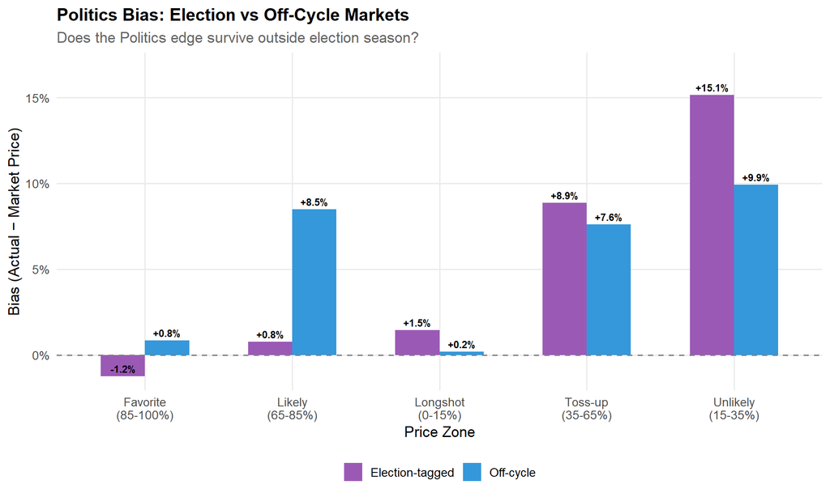

```r
politics_split <- snapshot_data %>%
  filter(snapshot_label == "1d", category == "Politics") %>%
  mutate(
    price_zone = case_when(
      snap_price <= 0.15 ~ "Longshot\n(0-15%)",
      snap_price <= 0.35 ~ "Unlikely\n(15-35%)",
      snap_price <= 0.65 ~ "Toss-up\n(35-65%)",
      snap_price <= 0.85 ~ "Likely\n(65-85%)",
      TRUE               ~ "Favorite\n(85-100%)"
    ),
    market_type = ifelse(is_election, "Election-tagged", "Off-cycle")
  ) %>%
  group_by(market_type, price_zone) %>%
  summarise(n = n(), bias = mean(yes_resolution) - mean(snap_price), .groups = "drop") %>%
  filter(n >= 10)

ggplot(politics_split, aes(x = price_zone, y = bias, fill = market_type)) +
  geom_col(position = "dodge", width = 0.6) +
  geom_hline(yintercept = 0, linetype = "dashed", color = "grey50") +
  geom_text(aes(label = paste0(ifelse(bias > 0,"+",""), round(bias*100,1),"%")),
            position = position_dodge(width = 0.6), vjust = -0.5, size = 3, fontface = "bold") +
  scale_fill_manual(values = c("Election-tagged" = "#9b59b6", "Off-cycle" = "#3498db")) +
  scale_y_continuous(labels = percent, expand = expansion(mult = c(0.05, 0.15))) +
  labs(
    title    = "Politics Bias: Election vs Off-Cycle Markets",
    subtitle = "Does the Politics edge survive outside election season?",
    x = "Price Zone", y = "Bias (Actual − Market Price)", fill = NULL
  )
```

```r
politics_agg <- snapshot_data %>%
  filter(snapshot_label == "1d", category == "Politics") %>%
  group_by(market_type = ifelse(is_election, "Election-tagged", "Off-cycle")) %>%
  summarise(
    n_markets       = n(),
    avg_price       = mean(snap_price),
    resolution_rate = mean(yes_resolution),
    bias            = mean(yes_resolution) - mean(snap_price),
    brier_score     = mean((snap_price - yes_resolution)^2),
    .groups         = "drop"
  )

politics_agg %>%
  mutate(across(where(is.numeric), ~ round(.x, 4))) %>%
  knitr::kable(caption = "Politics: Election vs Off-Cycle Bias (1 day before close)")
```

Politics: Election vs Off-Cycle Bias (1 day before close)

| market_type | n_markets | avg_price | resolution_rate | bias | brier_score |
| --- | --- | --- | --- | --- | --- |
| Election-tagged | 4476 | 0.2844 | 0.3213 | 0.0369 | 0.1054 |
| Off-cycle | 5196 | 0.1766 | 0.1940 | 0.0174 | 0.0497 |

# 4 · Volume-Weighted Analysis

Thin markets are noisier. Let’s check if bias patterns change when we weight by volume.

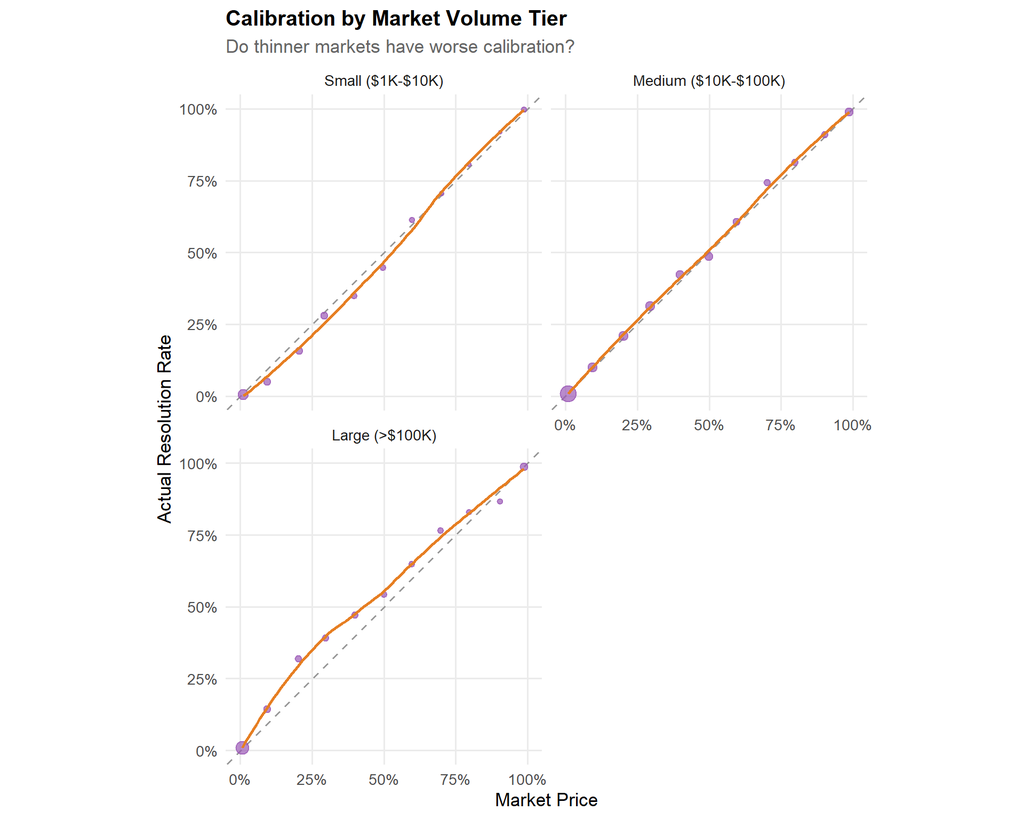

```r
vol_cal <- snapshot_data %>%
  filter(snapshot_label == "1d", !is.na(volume_num)) %>%
  mutate(
    vol_tier = case_when(
      volume_num < 1000   ~ "Micro (<$1K)",
      volume_num < 10000  ~ "Small ($1K-$10K)",
      volume_num < 100000 ~ "Medium ($10K-$100K)",
      TRUE                ~ "Large (>$100K)"
    ),
    vol_tier  = factor(vol_tier, levels = c(
      "Micro (<$1K)", "Small ($1K-$10K)", "Medium ($10K-$100K)", "Large (>$100K)"
    )),
    price_bin = round(snap_price * 10) / 10
  ) %>%
  group_by(vol_tier, price_bin) %>%
  summarise(n = n(), actual = mean(yes_resolution), predicted = mean(snap_price), .groups = "drop")

ggplot(vol_cal %>% filter(n >= 10), aes(x = predicted, y = actual)) +
  geom_abline(slope = 1, intercept = 0, linetype = "dashed", color = "grey60") +
  geom_point(aes(size = n), color = "#9b59b6", alpha = 0.7) +
  geom_smooth(aes(weight = n), method = "loess", se = FALSE, color = "#e67e22", linewidth = 1) +
  facet_wrap(~ vol_tier, ncol = 2) +
  scale_x_continuous(labels = percent, limits = c(0,1)) +
  scale_y_continuous(labels = percent, limits = c(0,1)) +
  scale_size_continuous(range = c(1,5), guide = "none") +
  coord_equal() +
  labs(
    title    = "Calibration by Market Volume Tier",
    subtitle = "Do thinner markets have worse calibration?",
    x = "Market Price", y = "Actual Resolution Rate"
  )
```

```r
vol_brier <- snapshot_data %>%
  filter(snapshot_label == "1d", !is.na(volume_num)) %>%
  mutate(
    vol_tier = case_when(
      volume_num < 1000   ~ "Micro (<$1K)",
      volume_num < 10000  ~ "Small ($1K-$10K)",
      volume_num < 100000 ~ "Medium ($10K-$100K)",
      TRUE                ~ "Large (>$100K)"
    ),
    vol_tier = factor(vol_tier, levels = c(
      "Micro (<$1K)", "Small ($1K-$10K)", "Medium ($10K-$100K)", "Large (>$100K)"
    )),
    brier = (snap_price - yes_resolution)^2
  ) %>%
  group_by(vol_tier) %>%
  summarise(n = n(), brier_score = mean(brier), bias = mean(yes_resolution - snap_price), .groups = "drop")

vol_brier %>%
  mutate(across(where(is.numeric) & !n, ~ round(.x, 4))) %>%
  knitr::kable(caption = "Brier Score & Bias by Volume Tier")
```

Brier Score & Bias by Volume Tier

| vol_tier | n | brier_score | bias |
| --- | --- | --- | --- |
| Small ($1K-$10K) | 8650 | 0.0917 | -0.0188 |
| Medium ($10K-$100K) | 26440 | 0.0958 | 0.0058 |
| Large (>$100K) | 13093 | 0.0872 | 0.0263 |

# 5 · Post-Breakout Over/Under Correction

**New.** A “breakout” is a large price move (≥10pp) within 24 hours. After such a move, does the price continue in the same direction (momentum) or reverse (overcorrection)? This is directly exploitable by a rule-based trading bot.

```r
library(data.table)

dfp_arrow2 <- open_dataset(
  "../data/markets_2025_closed_price_history.parquet"
)

valid_tokens <- market_stats %>%
  filter(market_duration_h >= 72, !is.na(volume_num), volume_num >= 5000) %>%
  pull(token_id)

cat(length(valid_tokens), "markets qualify for breakout analysis\n")
```

```
## 40351 markets qualify for breakout analysis
```

```r
# ── Collect all qualifying price history at once ──────────────────────
# data.table rolling join handles 19M rows fine — no batching needed
raw_dt <- dfp_arrow2 %>%
  filter(token_id %in% valid_tokens) %>%
  select(token_id, timestamp, price) %>%
  collect() %>%
  inner_join(
    market_stats %>% select(token_id, yes_resolution, category, closed_dt),
    by = "token_id"
  ) %>%
  as.data.table()

rm(dfp_arrow2)

raw_dt[, ts_sec            := as.numeric(timestamp)]
raw_dt[, hours_before_close := as.numeric(difftime(closed_dt, timestamp, units = "hours"))]
raw_dt  <- raw_dt[hours_before_close >= 0]
setorder(raw_dt, token_id, ts_sec)

# ── Rolling join: price 24h ago ───────────────────────────────────────
# For each observation, find nearest price where ts <= current_ts - 24h (within 4h tolerance)
lag_tbl <- raw_dt[, .(token_id, ts_target = ts_sec, price_lag = price)]
setkey(lag_tbl, token_id, ts_target)

raw_dt[, ts_minus24 := ts_sec - 86400]   # 24h in seconds
setkey(raw_dt, token_id, ts_minus24)

joined_lag <- lag_tbl[raw_dt, roll = 4 * 3600, rollends = c(TRUE, FALSE)]
# roll = 4*3600 means: match if within 4h tolerance, else NA
raw_dt[, price_24h_ago := joined_lag$price_lag]
raw_dt[, ts_minus24    := NULL]

# ── Rolling join: price 48h later ────────────────────────────────────
# Reverse the table to roll "forward"
fwd_tbl <- raw_dt[, .(token_id, ts_target = ts_sec, price_fwd = price)]
setkey(fwd_tbl, token_id, ts_target)

raw_dt[, ts_plus48 := ts_sec + 172800]   # 48h in seconds
setkey(raw_dt, token_id, ts_plus48)

# Nearest price AFTER current time: use negative roll (roll backward from future)
joined_fwd <- fwd_tbl[raw_dt, roll = -4 * 3600, rollends = c(FALSE, TRUE)]
raw_dt[, price_48h_later := joined_fwd$price_fwd]
raw_dt[, ts_plus48       := NULL]

# ── Compute breakouts ─────────────────────────────────────────────────
raw_dt[, `:=`(
  move_24h     = price - price_24h_ago,
  post_move    = price_48h_later - price
)]
raw_dt[, `:=`(
  is_breakout  = abs(move_24h) >= 0.10 & !is.na(price_24h_ago),
  continuation = sign(post_move) == sign(move_24h)
)]

breakouts <- raw_dt[
  is_breakout == TRUE & !is.na(post_move) & hours_before_close >= 48
] %>%
  as_tibble() %>%
  mutate(
    breakout_dir = ifelse(move_24h > 0, "Upward (price rose)", "Downward (price fell)"),
    move_size    = case_when(
      abs(move_24h) < 0.20 ~ "Small (10-20pp)",
      abs(move_24h) < 0.40 ~ "Medium (20-40pp)",
      TRUE                 ~ "Large (>40pp)"
    ),
    move_size = factor(move_size, levels = c("Small (10-20pp)", "Medium (20-40pp)", "Large (>40pp)"))
  )

rm(raw_dt, lag_tbl, joined_lag, fwd_tbl, joined_fwd); gc()
```

```
##            used  (Mb) gc trigger   (Mb)   max used    (Mb)
## Ncells  4940142 263.9    9375825  500.8    9375825   500.8
## Vcells 63906941 487.6 1142691488 8718.1 1428218670 10896.5
```

```r
cat(nrow(breakouts), "breakout events detected\n")
```

```
## 1212972 breakout events detected
```

```r
cat("Unique markets with ≥1 breakout:", n_distinct(breakouts$token_id), "\n")
```

```
## Unique markets with ≥1 breakout: 33591
```

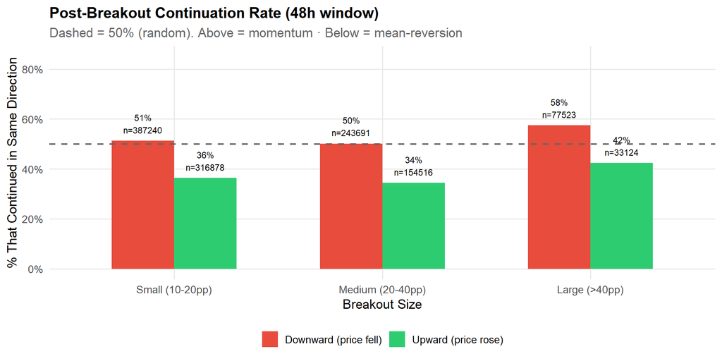

```r
bo_summary <- breakouts %>%
  group_by(breakout_dir, move_size) %>%
  summarise(
    n              = n(),
    continuation_r = mean(continuation, na.rm = TRUE),
    avg_post_move  = mean(post_move, na.rm = TRUE),
    .groups        = "drop"
  )

ggplot(bo_summary %>% filter(n >= 10),
       aes(x = move_size, y = continuation_r, fill = breakout_dir)) +
  geom_col(position = "dodge", width = 0.6) +
  geom_hline(yintercept = 0.5, linetype = "dashed", color = "grey40", linewidth = 0.8) +
  geom_text(aes(label = paste0(round(continuation_r*100,0), "%\nn=", n)),
            position = position_dodge(width = 0.6), vjust = -0.4, size = 3) +
  scale_fill_manual(values = c("Upward (price rose)" = COL_POS, "Downward (price fell)" = COL_NEG)) +
  scale_y_continuous(labels = percent, limits = c(0, 0.85)) +
  labs(
    title    = "Post-Breakout Continuation Rate (48h window)",
    subtitle = "Dashed = 50% (random). Above = momentum · Below = mean-reversion",
    x = "Breakout Size", y = "% That Continued in Same Direction", fill = NULL
  )
```

```r
bo_resolution <- breakouts %>%
  group_by(breakout_dir) %>%
  summarise(
    n               = n(),
    correct_dir_pct = mean(
      (move_24h > 0 & yes_resolution == 1) | (move_24h < 0 & yes_resolution == 0)
    ),
    avg_post_48h    = mean(post_move, na.rm = TRUE),
    .groups         = "drop"
  )

bo_resolution %>%
  mutate(across(where(is.numeric) & !n, ~ round(.x, 4))) %>%
  knitr::kable(caption = "Breakout Direction vs Eventual Resolution — Are Breakouts Informative?")
```

Breakout Direction vs Eventual Resolution — Are Breakouts Informative?

| breakout_dir | n | correct_dir_pct | avg_post_48h |
| --- | --- | --- | --- |
| Downward (price fell) | 708454 | 0.7792 | 0.0099 |
| Upward (price rose) | 504518 | 0.4349 | -0.0578 |

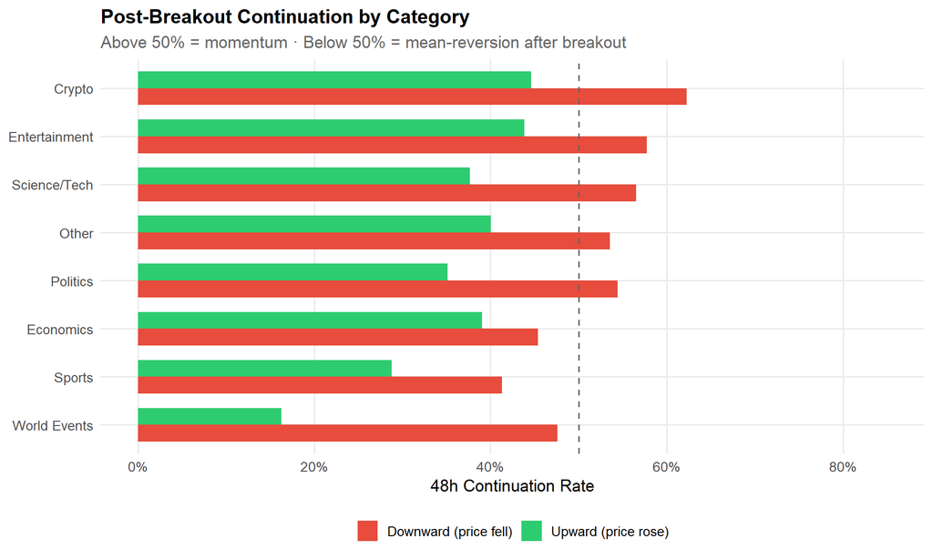

```r
bo_cat <- breakouts %>%
  group_by(category, breakout_dir) %>%
  summarise(
    n              = n(),
    continuation_r = mean(continuation, na.rm = TRUE),
    .groups        = "drop"
  ) %>%
  filter(n >= 15)

ggplot(bo_cat, aes(x = reorder(category, continuation_r), y = continuation_r, fill = breakout_dir)) +
  geom_col(position = "dodge", width = 0.7) +
  geom_hline(yintercept = 0.5, linetype = "dashed", color = "grey40") +
  scale_fill_manual(values = c("Upward (price rose)" = COL_POS, "Downward (price fell)" = COL_NEG)) +
  scale_y_continuous(labels = percent, limits = c(0, 0.85)) +
  coord_flip() +
  labs(
    title    = "Post-Breakout Continuation by Category",
    subtitle = "Above 50% = momentum · Below 50% = mean-reversion after breakout",
    x = NULL, y = "48h Continuation Rate", fill = NULL
  )
```

# 6 · Market Duration & Age Bias

**New.** Markets running for 1 week vs 6 months calibrate very differently. Longer markets attract more uncertainty at open; shorter ones may be efficiently priced from the start.

```r
duration_bias <- market_stats %>%
  filter(!is.na(market_duration_h), !is.na(initial_price), market_duration_h >= 1) %>%
  inner_join(
    snapshot_data %>%
      filter(snapshot_label == "1d") %>%
      select(id, snap_price) %>%
      rename(price_1d = snap_price),
    by = "id"
  ) %>%
  mutate(
    duration_tier = case_when(
      market_duration_h < 24   ~ "< 1 day",
      market_duration_h < 168  ~ "1-7 days",
      market_duration_h < 720  ~ "1-4 weeks",
      market_duration_h < 2160 ~ "1-3 months",
      TRUE                     ~ "> 3 months"
    ),
    duration_tier = factor(duration_tier, levels = c(
      "< 1 day","1-7 days","1-4 weeks","1-3 months","> 3 months"
    ))
  ) %>%
  group_by(duration_tier) %>%
  summarise(
    n             = n(),
    init_bias     = mean(yes_resolution - initial_price),
    final_bias    = mean(yes_resolution - price_1d),
    price_range   = mean(price_range, na.rm = TRUE),
    resolution_r  = mean(yes_resolution),
    brier_initial = mean((initial_price - yes_resolution)^2),
    .groups       = "drop"
  )

duration_bias %>%
  mutate(across(where(is.numeric), ~ round(.x, 4))) %>%
  knitr::kable(caption = "Bias & Calibration by Market Duration")
```

Bias & Calibration by Market Duration

| duration_tier | n | init_bias | final_bias | price_range | resolution_r | brier_initial |
| --- | --- | --- | --- | --- | --- | --- |
| < 1 day | 675 | -0.0300 | -0.0300 | 0.4651 | 0.4089 | 0.1925 |
| 1-7 days | 15075 | -0.1312 | 0.0109 | 0.5112 | 0.2825 | 0.2036 |
| 1-4 weeks | 24046 | -0.1422 | 0.0068 | 0.5304 | 0.2810 | 0.2057 |
| 1-3 months | 4915 | -0.2327 | 0.0025 | 0.4973 | 0.1727 | 0.1928 |
| > 3 months | 3472 | -0.2581 | 0.0044 | 0.4753 | 0.1129 | 0.1776 |

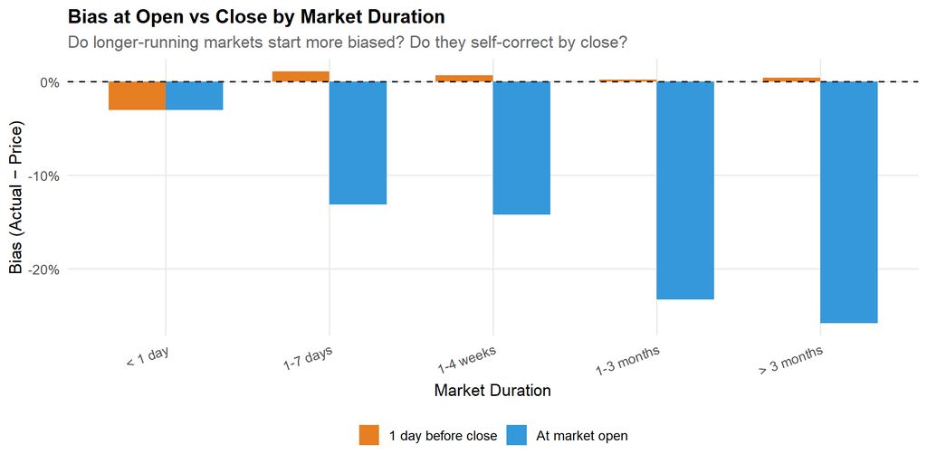

```r
duration_long <- duration_bias %>%
  select(duration_tier, n, init_bias, final_bias) %>%
  pivot_longer(c(init_bias, final_bias), names_to = "stage", values_to = "bias") %>%
  mutate(stage = recode(stage,
    init_bias  = "At market open",
    final_bias = "1 day before close"
  ))

ggplot(duration_long, aes(x = duration_tier, y = bias, fill = stage)) +
  geom_col(position = "dodge", width = 0.7) +
  geom_hline(yintercept = 0, linetype = "dashed") +
  scale_fill_manual(values = c("At market open" = "#3498db", "1 day before close" = "#e67e22")) +
  scale_y_continuous(labels = percent) +
  labs(
    title    = "Bias at Open vs Close by Market Duration",
    subtitle = "Do longer-running markets start more biased? Do they self-correct by close?",
    x = "Market Duration", y = "Bias (Actual − Price)", fill = NULL
  ) +
  theme(axis.text.x = element_text(angle = 20, hjust = 1))
```

# 7 · Temporal & Resolution Timing Patterns

**New.** Systematic biases based on *when* markets resolve. Day-of-week and monthly seasonality can generate exploitable patterns — sports markets resolve heavily on weekends, politics on election days, etc.

```r
temporal_data <- market_stats %>%
  filter(!is.na(closed_dt)) %>%
  mutate(
    close_month   = month(closed_dt),
    close_month   = factor(close_month, levels = 1:12,
                           labels = c("Jan","Feb","Mar","Apr","May","Jun",
                                      "Jul","Aug","Sep","Oct","Nov","Dec")),
    close_dow     = lubridate::wday(closed_dt, label = FALSE),   # 1=Sun, 2=Mon, ..., 7=Sat
    close_dow     = factor(close_dow, levels = c(2,3,4,5,6,7,1),
                           labels = c("Mon","Tue","Wed","Thu","Fri","Sat","Sun")),
    close_quarter = paste0("Q", lubridate::quarter(closed_dt))
  )
```

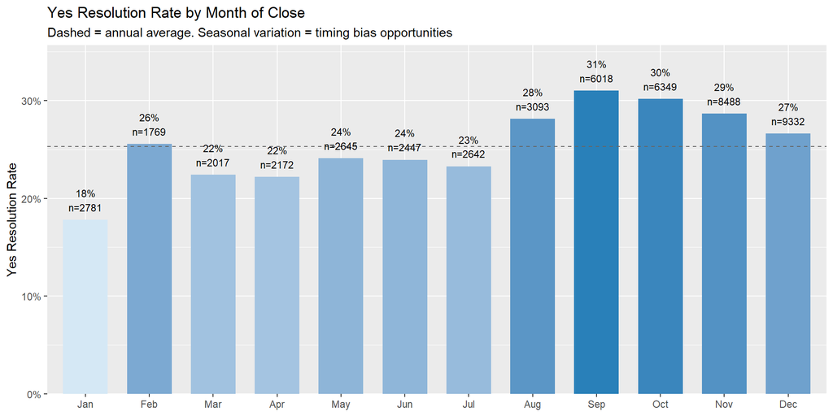

```r
monthly_bias <- temporal_data %>%
  filter(!is.na(initial_price)) %>%
  group_by(close_month) %>%
  summarise(n = n(), resolution_r = mean(yes_resolution),
            init_bias = mean(yes_resolution - initial_price), .groups = "drop")

ggplot(monthly_bias, aes(x = close_month, y = resolution_r)) +
  geom_col(aes(fill = resolution_r), width = 0.7, show.legend = FALSE) +
  geom_hline(yintercept = mean(monthly_bias$resolution_r), linetype = "dashed", color = "grey40") +
  geom_text(aes(label = paste0(round(resolution_r*100,0),"%\nn=",n)),
            vjust = -0.4, size = 3) +
  scale_fill_gradient(low = "#d5e8f5", high = "#2980b9") +
  scale_y_continuous(labels = percent, expand = expansion(mult = c(0, 0.15))) +
  labs(
    title    = "Yes Resolution Rate by Month of Close",
    subtitle = "Dashed = annual average. Seasonal variation = timing bias opportunities",
    x = NULL, y = "Yes Resolution Rate"
  )
```

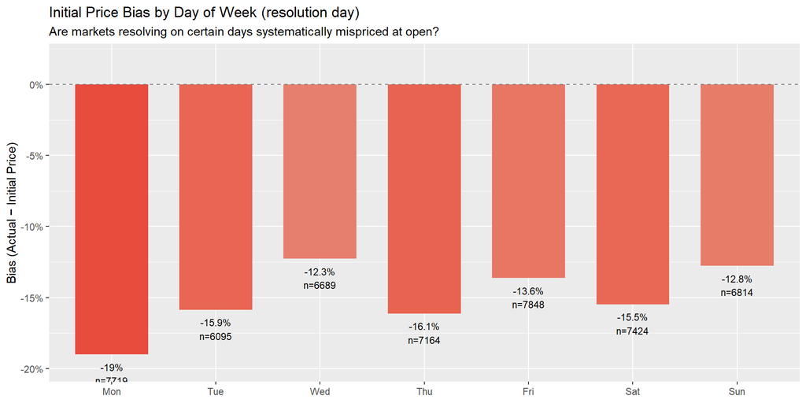

```r
dow_bias <- temporal_data %>%
  filter(!is.na(initial_price)) %>%
  group_by(close_dow) %>%
  summarise(n = n(), resolution_r = mean(yes_resolution),
            init_bias = mean(yes_resolution - initial_price), .groups = "drop")

ggplot(dow_bias, aes(x = close_dow, y = init_bias)) +
  geom_col(aes(fill = init_bias), width = 0.7, show.legend = FALSE) +
  geom_hline(yintercept = 0, linetype = "dashed", color = "grey50") +
  geom_text(aes(label = paste0(ifelse(init_bias > 0,"+",""), round(init_bias*100,1),"%\nn=",n)),
            vjust = ifelse(dow_bias$init_bias >= 0, -0.4, 1.4), size = 3) +
  scale_fill_gradient2(low = COL_NEG, mid = "grey80", high = COL_POS, midpoint = 0) +
  scale_y_continuous(labels = percent, expand = expansion(mult = c(0.1, 0.15))) +
  labs(
    title    = "Initial Price Bias by Day of Week (resolution day)",
    subtitle = "Are markets resolving on certain days systematically mispriced at open?",
    x = NULL, y = "Bias (Actual − Initial Price)"
  )
```

```r
quarterly_cal <- snapshot_data %>%
  filter(snapshot_label == "1d") %>%
  left_join(market_stats %>% select(id, closed_dt), by = "id") %>%
  mutate(quarter = paste0("Q", quarter(closed_dt))) %>%
  filter(!is.na(quarter)) %>%
  group_by(quarter) %>%
  summarise(
    n           = n(),
    bias        = mean(yes_resolution - snap_price),
    brier_score = mean((snap_price - yes_resolution)^2),
    abs_bias    = mean(abs(yes_resolution - snap_price)),
    .groups     = "drop"
  )

quarterly_cal %>%
  mutate(across(where(is.numeric) & !n, ~ round(.x, 4))) %>%
  knitr::kable(caption = "Calibration by Quarter — Is the market getting more efficient over time?")
```

Calibration by Quarter — Is the market getting more efficient over time?

| quarter | n | bias | brier_score | abs_bias |
| --- | --- | --- | --- | --- |
| Q1 | 6474 | -0.0006 | 0.0736 | 0.1466 |
| Q2 | 7213 | 0.0070 | 0.0890 | 0.1792 |
| Q3 | 10443 | 0.0078 | 0.0965 | 0.1922 |
| Q4 | 24053 | 0.0086 | 0.0974 | 0.1933 |

# 7.5 · Day-of-Week Bias by Category

**New.** Different categories resolve on different days. Sports on weekends, politics on weekdays. Do mispricing patterns differ by day × category?

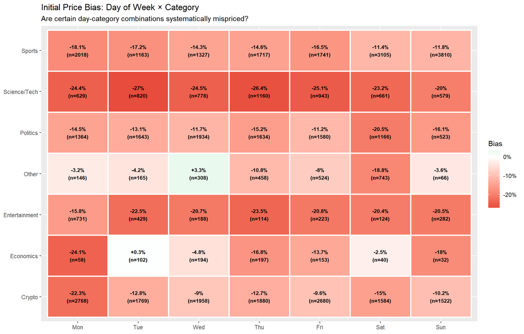

```r
dow_cat <- temporal_data %>%
  filter(!is.na(initial_price), !is.na(close_dow)) %>%
  group_by(close_dow, category) %>%
  summarise(
    n         = n(),
    init_bias = mean(yes_resolution - initial_price),
    .groups   = "drop"
  ) %>%
  filter(n >= 20)

ggplot(dow_cat, aes(x = close_dow, y = category, fill = init_bias)) +
  geom_tile(color = "white", linewidth = 1) +
  geom_text(aes(label = ifelse(n >= 20,
    paste0(ifelse(init_bias > 0,"+",""), round(init_bias*100,1),"%\n(n=",n,")"), "")),
    size = 2.8, fontface = "bold") +
  scale_fill_gradient2(low = COL_NEG, mid = "white", high = COL_POS, midpoint = 0,
                       labels = percent, name = "Bias") +
  labs(
    title    = "Initial Price Bias: Day of Week × Category",
    subtitle = "Are certain day-category combinations systematically mispriced?",
    x = NULL, y = NULL
  )
```

# 7.6 · New Market Opening Window

**New.** The initial price bias of −15.7% suggests a systematic “buy Yes on new markets” edge. We test how quickly this corrects — is the best window the first hour, first day, or first week?

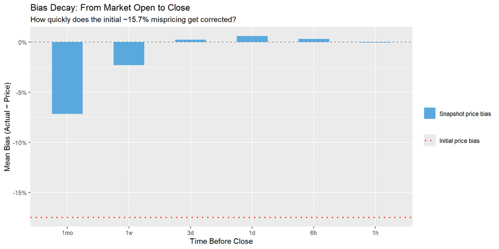

```r
# Compare initial bias magnitude by how soon the snapshot is relative to market creation
opening_window <- snapshot_data %>%
  inner_join(
    market_stats %>% select(id, initial_price, market_duration_h),
    by = "id"
  ) %>%
  filter(!is.na(initial_price), market_duration_h >= 168) %>%   # only markets lasting 1wk+
  mutate(
    snapshot_label = factor(snapshot_label, levels = c("1mo","1w","3d","1d","6h","1h")),
    snap_bias      = yes_resolution - snap_price,
    init_bias      = yes_resolution - initial_price
  ) %>%
  group_by(snapshot_label) %>%
  summarise(
    n         = n(),
    snap_bias = mean(snap_bias),
    init_bias = mean(init_bias),
    .groups   = "drop"
  )

ggplot(opening_window, aes(x = snapshot_label)) +
  geom_hline(yintercept = 0, linetype = "dashed", color = "grey50") +
  geom_col(aes(y = snap_bias, fill = "Snapshot price bias"), width = 0.5, alpha = 0.8) +
  geom_hline(aes(yintercept = mean(opening_window$init_bias), color = "Initial price bias"),
             linetype = "dotted", linewidth = 1) +
  scale_fill_manual(values = c("Snapshot price bias" = "#3498db")) +
  scale_color_manual(values = c("Initial price bias" = COL_NEG)) +
  scale_y_continuous(labels = percent) +
  labs(
    title    = "Bias Decay: From Market Open to Close",
    subtitle = "How quickly does the initial −15.7% mispricing get corrected?",
    x = "Time Before Close", y = "Mean Bias (Actual − Price)", fill = NULL, color = NULL
  )
```

# 7.7 · Volume Surge as Directional Signal

**New.** Do sudden volume spikes predict resolution direction? If informed traders enter aggressively, volume surges might precede the correct outcome.

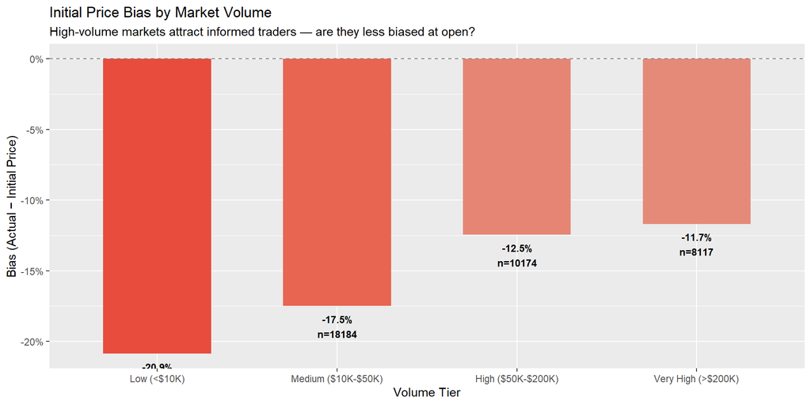

```r
vol_surge <- market_stats %>%
  filter(!is.na(volume_num), !is.na(initial_price), !is.na(final_price),
         market_duration_h >= 48) %>%
  mutate(
    vol_tier = case_when(
      volume_num < 10000  ~ "Low (<$10K)",
      volume_num < 50000  ~ "Medium ($10K-$50K)",
      volume_num < 200000 ~ "High ($50K-$200K)",
      TRUE                ~ "Very High (>$200K)"
    ),
    vol_tier = factor(vol_tier, levels = c(
      "Low (<$10K)", "Medium ($10K-$50K)", "High ($50K-$200K)", "Very High (>$200K)"
    )),
    price_move = final_price - initial_price,
    resolution_surprise = abs(yes_resolution - initial_price)
  ) %>%
  group_by(vol_tier) %>%
  summarise(
    n                = n(),
    resolution_rate  = mean(yes_resolution),
    avg_price_move   = mean(price_move),
    avg_surprise     = mean(resolution_surprise),
    brier_init       = mean((initial_price - yes_resolution)^2),
    init_bias        = mean(yes_resolution - initial_price),
    .groups          = "drop"
  )

ggplot(vol_surge, aes(x = vol_tier, y = init_bias)) +
  geom_col(aes(fill = init_bias), width = 0.6, show.legend = FALSE) +
  geom_hline(yintercept = 0, linetype = "dashed", color = "grey50") +
  geom_text(aes(label = paste0(ifelse(init_bias > 0,"+",""),
                                round(init_bias*100,1), "%\nn=", n)),
            vjust = ifelse(vol_surge$init_bias >= 0, -0.4, 1.4), size = 3.2, fontface = "bold") +
  scale_fill_gradient2(low = COL_NEG, mid = "grey80", high = COL_POS, midpoint = 0) +
  scale_y_continuous(labels = percent) +
  labs(
    title    = "Initial Price Bias by Market Volume",
    subtitle = "High-volume markets attract informed traders — are they less biased at open?",
    x = "Volume Tier", y = "Bias (Actual − Initial Price)"
  )
```

# 7.8 · Asymmetric Error: Over- vs Under-priced Markets

**New.** Do markets make bigger errors when overpricing Yes (price > resolution) vs underpricing Yes? If the error is asymmetric, it tells us which side of the trade is systematically more profitable.

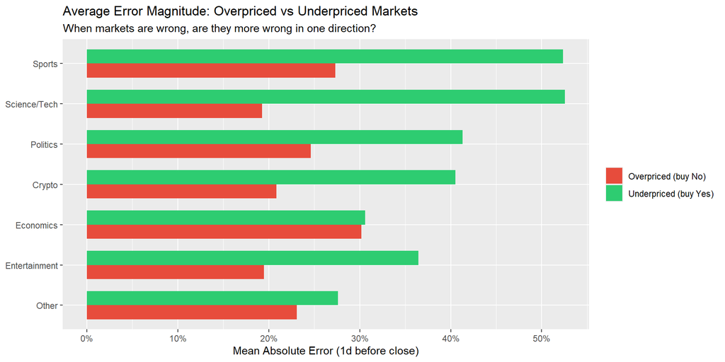

```r
asym_data <- snapshot_data %>%
  filter(snapshot_label == "1d") %>%
  mutate(
    error     = yes_resolution - snap_price,
    error_dir = case_when(
      error >  0.02 ~ "Underpriced (buy Yes)",
      error < -0.02 ~ "Overpriced (buy No)",
      TRUE          ~ "Approximately correct"
    )
  )

asym_summary <- asym_data %>%
  group_by(error_dir) %>%
  summarise(
    n           = n(),
    pct         = n() / nrow(asym_data),
    avg_error   = mean(abs(error)),
    avg_profit  = mean(abs(error) * ifelse(error_dir != "Approximately correct", 1, 0)),
    .groups     = "drop"
  )

asym_cat <- asym_data %>%
  filter(error_dir != "Approximately correct") %>%
  group_by(category, error_dir) %>%
  summarise(n = n(), avg_abs_error = mean(abs(error)), .groups = "drop") %>%
  filter(n >= 20)

ggplot(asym_cat, aes(x = reorder(category, avg_abs_error), y = avg_abs_error, fill = error_dir)) +
  geom_col(position = "dodge", width = 0.7) +
  scale_fill_manual(values = c("Underpriced (buy Yes)" = COL_POS, "Overpriced (buy No)" = COL_NEG)) +
  scale_y_continuous(labels = percent) +
  coord_flip() +
  labs(
    title    = "Average Error Magnitude: Overpriced vs Underpriced Markets",
    subtitle = "When markets are wrong, are they more wrong in one direction?",
    x = NULL, y = "Mean Absolute Error (1d before close)", fill = NULL
  )
```

```r
asym_summary %>%
  mutate(across(c(pct, avg_error, avg_profit), ~ round(.x, 4))) %>%
  knitr::kable(caption = "Asymmetric Error Distribution (1d before close)")
```

Asymmetric Error Distribution (1d before close)

| error_dir | n | pct | avg_error | avg_profit |
| --- | --- | --- | --- | --- |
| Approximately correct | 20562 | 0.4267 | 0.0048 | 0.0000 |
| Overpriced (buy No) | 17445 | 0.3621 | 0.2406 | 0.2406 |
| Underpriced (buy Yes) | 10176 | 0.2112 | 0.4521 | 0.4521 |

# 7.9 · Spread Between Correlated Snapshots

**New.** If the 1-week price and 1-day price for the same market diverge substantially, it signals either new information or a slow-moving correction. Markets where the 1w→1d price *increased* but resolution was 0 (or vice versa) may indicate exploitable late-stage mispricing.

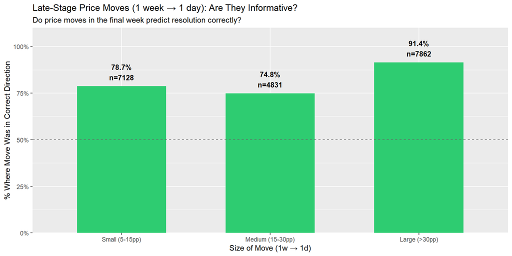

```r
snap_divergence <- snapshot_data %>%
  select(id, snapshot_label, snap_price, yes_resolution, category) %>%
  filter(snapshot_label %in% c("1w", "1d")) %>%
  pivot_wider(names_from = snapshot_label, values_from = snap_price,
              names_prefix = "price_") %>%
  filter(!is.na(price_1w), !is.na(price_1d)) %>%
  mutate(
    late_move     = price_1d - price_1w,
    move_correct  = (late_move > 0 & yes_resolution == 1) | (late_move < 0 & yes_resolution == 0),
    move_size_abs = abs(late_move),
    move_bucket   = case_when(
      move_size_abs < 0.05 ~ "Tiny (<5pp)",
      move_size_abs < 0.15 ~ "Small (5-15pp)",
      move_size_abs < 0.30 ~ "Medium (15-30pp)",
      TRUE                 ~ "Large (>30pp)"
    ),
    move_bucket = factor(move_bucket, levels = c("Tiny (<5pp)","Small (5-15pp)",
                                                  "Medium (15-30pp)","Large (>30pp)"))
  )

late_move_summary <- snap_divergence %>%
  filter(move_size_abs >= 0.05) %>%    # only meaningful moves
  group_by(move_bucket) %>%
  summarise(
    n                = n(),
    pct_correct      = mean(move_correct),
    avg_move         = mean(late_move),
    resolution_rate  = mean(yes_resolution),
    .groups          = "drop"
  )

ggplot(late_move_summary, aes(x = move_bucket, y = pct_correct)) +
  geom_col(aes(fill = pct_correct > 0.5), width = 0.6, show.legend = FALSE) +
  geom_hline(yintercept = 0.5, linetype = "dashed", color = "grey40") +
  geom_text(aes(label = paste0(round(pct_correct*100,1),"%\nn=",n)),
            vjust = -0.4, size = 3.5, fontface = "bold") +
  scale_fill_manual(values = c("FALSE" = COL_NEG, "TRUE" = COL_POS)) +
  scale_y_continuous(labels = percent, limits = c(0, 1), expand = expansion(mult = c(0, 0.1))) +
  labs(
    title    = "Late-Stage Price Moves (1 week → 1 day): Are They Informative?",
    subtitle = "Do price moves in the final week predict resolution correctly?",
    x = "Size of Move (1w → 1d)", y = "% Where Move Was in Correct Direction"
  )
```

# 8 · Exploitable Pattern Summary (with Bootstrap CIs)

```r
exploitable <- snapshot_data %>%
  filter(snapshot_label == "1d") %>%
  mutate(
    price_zone = case_when(
      snap_price <= 0.15 ~ "Longshot (0-15%)",
      snap_price <= 0.35 ~ "Unlikely (15-35%)",
      snap_price <= 0.65 ~ "Toss-up (35-65%)",
      snap_price <= 0.85 ~ "Likely (65-85%)",
      TRUE               ~ "Favorite (85-100%)"
    )
  ) %>%
  group_by(category, price_zone) %>%
  summarise(
    n_markets   = n(),
    avg_price   = mean(snap_price),
    actual_rate = mean(yes_resolution),
    bias        = mean(yes_resolution) - mean(snap_price),
    edge_pct    = bias / avg_price * 100,
    brier       = mean((snap_price - yes_resolution)^2),
    .groups     = "drop"
  ) %>%
  filter(n_markets >= 15, abs(bias) > 0.03) %>%
  arrange(desc(abs(bias)))

exploitable %>%
  mutate(across(where(is.numeric) & !n_markets, ~ round(.x, 3))) %>%
  head(20) %>%
  knitr::kable(caption = "Top 20 Most Exploitable Category × Price Zone Combinations (|bias| > 3%, n ≥ 15)")
```

Top 20 Most Exploitable Category × Price Zone Combinations (|bias| > 3%, n ≥ 15)

| category | price_zone | n_markets | avg_price | actual_rate | bias | edge_pct | brier |
| --- | --- | --- | --- | --- | --- | --- | --- |
| Politics | Unlikely (15-35%) | 731 | 0.253 | 0.382 | 0.129 | 51.071 | 0.247 |
| Politics | Toss-up (35-65%) | 1170 | 0.502 | 0.586 | 0.084 | 16.802 | 0.247 |
| Science/Tech | Toss-up (35-65%) | 678 | 0.465 | 0.388 | -0.077 | -16.506 | 0.232 |
| Science/Tech | Unlikely (15-35%) | 822 | 0.251 | 0.189 | -0.062 | -24.751 | 0.155 |
| Entertainment | Likely (65-85%) | 93 | 0.756 | 0.806 | 0.050 | 6.656 | 0.152 |
| Other | Likely (65-85%) | 174 | 0.761 | 0.810 | 0.049 | 6.471 | 0.156 |
| Crypto | Likely (65-85%) | 557 | 0.751 | 0.799 | 0.048 | 6.371 | 0.164 |
| Crypto | Toss-up (35-65%) | 1331 | 0.482 | 0.527 | 0.046 | 9.444 | 0.243 |
| Economics | Favorite (85-100%) | 116 | 0.945 | 0.983 | 0.038 | 3.976 | 0.019 |
| Politics | Likely (65-85%) | 615 | 0.749 | 0.782 | 0.033 | 4.470 | 0.169 |

```r
snap_1d <- snapshot_data %>%
  filter(snapshot_label == "1d") %>%
  mutate(
    price_zone = case_when(
      snap_price <= 0.15 ~ "Longshot (0-15%)",
      snap_price <= 0.35 ~ "Unlikely (15-35%)",
      snap_price <= 0.65 ~ "Toss-up (35-65%)",
      snap_price <= 0.85 ~ "Likely (65-85%)",
      TRUE               ~ "Favorite (85-100%)"
    )
  )

boot_bias_fn <- function(data, indices) {
  d <- data[indices, ]
  mean(d$yes_resolution) - mean(d$snap_price)
}

# Run bootstrap outside rowwise — avoids list-column extraction issues
top_segments <- exploitable %>% head(15) %>% select(category, price_zone)

ci_results <- pmap_dfr(top_segments, function(category, price_zone) {
  seg <- snap_1d %>% filter(category == .env$category, price_zone == .env$price_zone)
  n_obs      <- nrow(seg)
  point_bias <- mean(seg$yes_resolution) - mean(seg$snap_price)

  ci_lo <- NA_real_
  ci_hi <- NA_real_

  if (n_obs >= 30) {
    bo <- boot(seg, boot_bias_fn, R = 1000)
    ci <- boot.ci(bo, type = "perc")
    if (!is.null(ci$percent)) {
      ci_lo <- ci$percent[4]
      ci_hi <- ci$percent[5]
    }
  }

  tibble(
    category    = category,
    price_zone  = price_zone,
    n_obs       = n_obs,
    point_bias  = point_bias,
    ci_lo       = ci_lo,
    ci_hi       = ci_hi,
    significant = !is.na(ci_lo) & (ci_lo > 0 | ci_hi < 0)
  )
})

ci_results %>%
  mutate(
    across(c(point_bias, ci_lo, ci_hi), ~ paste0(round(.x * 100, 2), "%")),
    significant = ifelse(significant, "YES", "no")
  ) %>%
  knitr::kable(caption = "Bootstrap 95% CIs — Which Edges Are Statistically Real?")
```

Bootstrap 95% CIs — Which Edges Are Statistically Real?

| category | price_zone | n_obs | point_bias | ci_lo | ci_hi | significant |
| --- | --- | --- | --- | --- | --- | --- |
| Politics | Unlikely (15-35%) | 731 | 12.9% | 9.67% | 16.41% | YES |
| Politics | Toss-up (35-65%) | 1170 | 8.43% | 5.7% | 11.21% | YES |
| Science/Tech | Toss-up (35-65%) | 678 | -7.67% | -11.17% | -4.19% | YES |
| Science/Tech | Unlikely (15-35%) | 822 | -6.2% | -8.94% | -3.53% | YES |
| Entertainment | Likely (65-85%) | 93 | 5.03% | -2.56% | 12.59% | no |
| Other | Likely (65-85%) | 174 | 4.93% | -0.89% | 10.76% | no |
| Crypto | Likely (65-85%) | 557 | 4.79% | 1.39% | 7.88% | YES |
| Crypto | Toss-up (35-65%) | 1331 | 4.55% | 1.95% | 7.27% | YES |
| Economics | Favorite (85-100%) | 116 | 3.76% | 1.13% | 5.82% | YES |
| Politics | Likely (65-85%) | 615 | 3.35% | -0.01% | 6.6% | no |

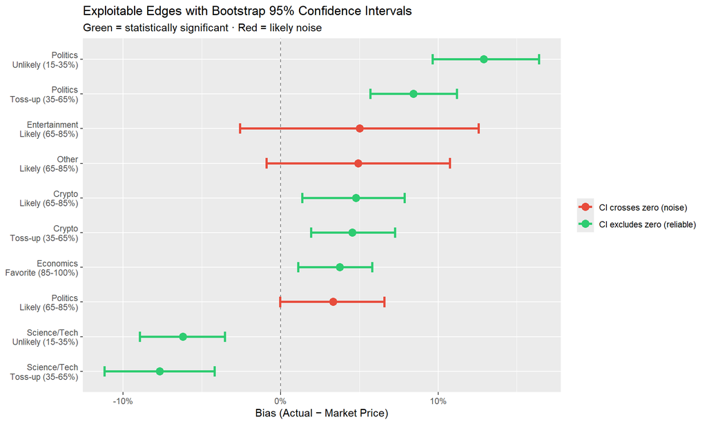

```r
ci_plot <- ci_results %>%
  filter(!is.na(ci_lo)) %>%
  mutate(label = paste(category, price_zone, sep = "\n"))

ggplot(ci_plot, aes(x = reorder(label, point_bias), y = point_bias)) +
  geom_hline(yintercept = 0, linetype = "dashed", color = "grey50") +
  geom_errorbar(aes(ymin = ci_lo, ymax = ci_hi, color = significant),
                width = 0.3, linewidth = 1.2) +
  geom_point(aes(color = significant), size = 3.5) +
  scale_color_manual(
    values = c("TRUE" = COL_POS, "FALSE" = COL_NEG),
    labels = c("TRUE" = "CI excludes zero (reliable)", "FALSE" = "CI crosses zero (noise)")
  ) +
  scale_y_continuous(labels = percent) +
  coord_flip() +
  labs(
    title    = "Exploitable Edges with Bootstrap 95% Confidence Intervals",
    subtitle = "Green = statistically significant · Red = likely noise",
    x = NULL, y = "Bias (Actual − Market Price)", color = NULL
  )
```

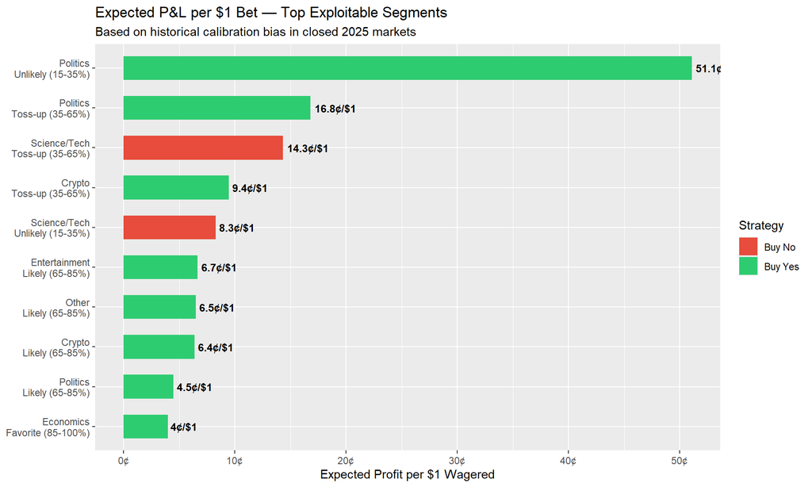

```r
exploitable_pl <- exploitable %>%
  mutate(
    strategy    = ifelse(bias > 0, "Buy Yes", "Buy No"),
    expected_pl = ifelse(
      bias > 0,
      actual_rate * (1 / avg_price - 1) - (1 - actual_rate),
      (1 - actual_rate) * (1 / (1 - avg_price) - 1) - actual_rate
    ),
    label = paste(category, price_zone, sep = "\n")
  )

ggplot(exploitable_pl %>% head(15),
       aes(x = reorder(label, expected_pl), y = expected_pl)) +
  geom_col(aes(fill = strategy), width = 0.6) +
  geom_text(aes(label = paste0(round(expected_pl*100,1),"¢/$1")),
            hjust = ifelse(exploitable_pl$expected_pl[1:min(15,nrow(exploitable_pl))] >= 0, -0.1, 1.1),
            size = 3.3, fontface = "bold") +
  scale_fill_manual(values = c("Buy Yes" = COL_POS, "Buy No" = COL_NEG)) +
  scale_y_continuous(labels = function(x) paste0(round(x*100,1),"¢")) +
  coord_flip() +
  labs(
    title    = "Expected P&L per $1 Bet — Top Exploitable Segments",
    subtitle = "Based on historical calibration bias in closed 2025 markets",
    x = NULL, y = "Expected Profit per $1 Wagered", fill = "Strategy"
  )
```

# 9 · Key Takeaways

```r
overall_bias <- snapshot_data %>%
  filter(snapshot_label == "1d") %>%
  summarise(bias = mean(yes_resolution) - mean(snap_price)) %>%
  pull(bias)

worst_cat   <- cat_stats %>% slice_max(abs(bias), n = 1)
best_cat    <- cat_stats %>% slice_min(brier_score, n = 1)
top_exploit <- exploitable %>% slice(1)

overall_init_bias <- market_stats %>%
  filter(!is.na(initial_price), market_duration_h >= 24) %>%
  summarise(bias = mean(yes_resolution - initial_price)) %>%
  pull(bias)

overall_continuation <- if (nrow(breakouts) > 0) mean(breakouts$continuation, na.rm = TRUE) else NA_real_
n_sig <- sum(ci_results$significant, na.rm = TRUE)

cat("## Automated Findings\n\n")
```

## Automated Findings

```r
cat(sprintf("- **Overall market bias** (1d before close): %+.1f%%. %s.\n",
  overall_bias * 100,
  ifelse(overall_bias > 0.01, "Markets slightly underprice Yes outcomes",
  ifelse(overall_bias < -0.01, "Markets slightly overprice Yes outcomes",
  "Markets are approximately well-calibrated overall"))))
```

- **Overall market bias** (1d before close): +0.7%. Markets are approximately well-calibrated overall.

```r
cat(sprintf("- **Initial price bias** (at market open): %+.1f%%. This is %s than 1-day bias — %s.\n",
  overall_init_bias * 100,
  ifelse(abs(overall_init_bias) > abs(overall_bias), "**larger**", "smaller"),
  ifelse(abs(overall_init_bias) > abs(overall_bias),
    "the best mispricing window is right after market creation",
    "prices are reasonably set at open and the bias accumulates later")))
```

- **Initial price bias** (at market open): -15.7%. This is **larger** than 1-day bias — the best mispricing window is right after market creation.

```r
cat(sprintf("- **Most biased category**: %s (%+.1f%% bias, n=%d)\n",
  worst_cat$category, worst_cat$bias * 100, worst_cat$n_markets))
```

- **Most biased category**: World Events (+10.8% bias, n=18)

```r
cat(sprintf("- **Best calibrated category**: %s (Brier score: %.4f)\n",
  best_cat$category, best_cat$brier_score))
```

- **Best calibrated category**: Entertainment (Brier score: 0.0473)

```r
if (nrow(top_exploit) > 0) {
  cat(sprintf("- **Largest exploitable edge**: %s × %s (%+.1f%% bias, n=%d)\n",
    top_exploit$category, top_exploit$price_zone,
    top_exploit$bias * 100, top_exploit$n_markets))
}
```

- **Largest exploitable edge**: Politics × Unlikely (15-35%) (+12.9% bias, n=731)

```r
if (!is.na(overall_continuation)) {
  cat(sprintf("- **Post-breakout behaviour**: %.0f%% of breakouts continue in the same direction over 48h. %s.\n",
    overall_continuation * 100,
    ifelse(overall_continuation > 0.55, "Momentum dominates — breakouts tend to persist",
    ifelse(overall_continuation < 0.45, "Mean-reversion dominates — fading breakouts may be profitable",
    "No clear momentum or reversion signal"))))
}
```

- **Post-breakout behaviour**: 45% of breakouts continue in the same direction over 48h. No clear momentum or reversion signal.

```r
cat(sprintf("- **Statistically reliable edges**: %d/%d top segments have bootstrap CIs excluding zero.\n",
  n_sig, nrow(ci_results)))
```

- **Statistically reliable edges**: 7/10 top segments have bootstrap CIs excluding zero.

```r
cat("\n\n---\n\n")
```

```r
cat("> **Disclaimer**: Past calibration patterns do not guarantee future exploitability. Transaction costs, slippage, and market evolution may erode these edges. Always paper-trade or use minimal size before scaling.\n")
```

> **Disclaimer**: Past calibration patterns do not guarantee future exploitability. Transaction costs, slippage, and market evolution may erode these edges. Always paper-trade or use minimal size before scaling.

*Analysis generated on 2026-02-18 using 49753 closed binary markets and price history data.*